# Education vs. Obesity Rate

## By Timothy Chu

[figure not shown]

Image from Block Club Chicago

## Introduction

The data science pipeline is the use of technology to analyze large amounts of data and be able to draw conclusions from them. I've always had the question: does education correlate with obesity level? From a common sense viewpoint, it seems like there has to be: that less educated people tend to eat less healthy foods and exercise less, possibly leading to higher rates of obesity. The question is whether that "common sense" hypothesis is supported by the data. I believe it is really important to be able to back up this thinking or have it debunked by the data. I see to answer this question by utilizing my data science skills.

## Data Collection

I gathered my data from two sources: the CDC's obesity dataset at https://www.cdc.gov/obesity/data/, and Data.gov's education dataset at https://catalog.data.gov/dataset/choose-maryland-compare-states-education. Both of these are respected government agencies that organize high quality data. I picked these datasets because they contained relevant information that I would need in this analysis.

Let's focus on the obesity data first. The obesity data from the CDC gives us a whole decades worth of yearly obesity values from every state plus DC and a few territories. The education data from from Data.gov gives us a several different metrics of education levels in the 50 states plus DC. I decided I would do this comparison on the state level because that seemed the easiest way to analyze a correlation since the states have large variations in education level and obesity level.

You'll want the following five libaries (these are some of the most popular libraries used by data scientists): Pandas, Numpy, Seaborn, StatsModels, and Matplotlib

Let's first start by putting our data in some Pandas dataframes.

```python
#allows us to use dataframes and plot certain plots
import pandas as pd
#allows us to use numpy arrays perform operations on series
import numpy as np
#for graphing regression lines
import seaborn as sns
import statsmodels.api as sm
#for computing regression information
import matplotlib.pyplot as plt
#for creating plots

#read the CSV file and put it in a dataframe
obesity = pd.read_csv("./obesity_data.csv")
#display the first few rows of the dataframe
obesity.head()
```

|  | ID | YearStart | YearEnd | Description | LocationAbbr | LocationDesc | DataSource | Class | Topic | Question | ... | StratificationId2 | StratificationCategory3 | StratificationCategoryId3 | Stratification3 | StratificationId3 | LocationDisplayOrder | FootnoteSymbol | FootnoteText | URL | FootnoteHeading |
| --- | --- | --- | --- | --- | --- | --- | --- | --- | --- | --- | --- | --- | --- | --- | --- | --- | --- | --- | --- | --- | --- |
| 0 | 69107.0 | 2011.0 | 2011.0 | 2011.0 | US | National | BRFSS | Obesity / Weight Status | Obesity / Weight Status | Percent of adults aged 18 years and older who ... | ... | NaN | NaN | NaN | NaN | NaN | 0.0 | NaN | NaN | NaN | NaN |
| 1 | 70813.0 | 2012.0 | 2012.0 | 2012.0 | US | National | BRFSS | Obesity / Weight Status | Obesity / Weight Status | Percent of adults aged 18 years and older who ... | ... | NaN | NaN | NaN | NaN | NaN | 0.0 | NaN | NaN | NaN | NaN |
| 2 | 62702.0 | 2013.0 | 2013.0 | 2013.0 | US | National | BRFSS | Obesity / Weight Status | Obesity / Weight Status | Percent of adults aged 18 years and older who ... | ... | NaN | NaN | NaN | NaN | NaN | 0.0 | NaN | NaN | NaN | NaN |
| 3 | 67007.0 | 2014.0 | 2014.0 | 2014.0 | US | National | BRFSS | Obesity / Weight Status | Obesity / Weight Status | Percent of adults aged 18 years and older who ... | ... | NaN | NaN | NaN | NaN | NaN | 0.0 | NaN | NaN | NaN | NaN |
| 4 | 68256.0 | 2015.0 | 2015.0 | 2015.0 | US | National | BRFSS | Obesity / Weight Status | Obesity / Weight Status | Percent of adults aged 18 years and older who ... | ... | NaN | NaN | NaN | NaN | NaN | 0.0 | NaN | NaN | NaN | NaN |

5 rows × 43 columns

Next is the education data:

```python
education = pd.read_csv("./education_data.csv")
education.head()
```

|  | State | Public School Student-Teacher Ratio, K-12 | Public School Expenditures Per Pupil, K-12 ($ Dollars) | Average Salary for Public School Teachers, K-12 ($ Dollars) | High School Attainment (%) | Bachelor's Degree Attainment (%) | Graduate Degree Attainment (%) | Annual College Graduates | Number of 2-Year Colleges | Number of 4-Year Colleges and Universities |
| --- | --- | --- | --- | --- | --- | --- | --- | --- | --- | --- |
| 0 | Alabama | 17.5 | 9257 | 50239 | 86.6 | 25.5 | 9.5 | 60282 | 30 | 42 |
| 1 | Alaska | 17 | 17509 | 69474 | 93.3 | 30.2 | 11.7 | 4051 | 2 | 6 |
| 2 | Arizona | 23.3 | 7772 | 47746 | 87.5 | 29.7 | 11.2 | 116243 | 36 | 42 |
| 3 | Arkansas | 13.8 | 9900 | 49017 | 87.2 | 23.3 | 8.6 | 31878 | 27 | 26 |
| 4 | California | 23.3 | 11420 | 81126 | 83.8 | 34.2 | 12.9 | 461909 | 172 | 269 |

Awesome. We've grabbed all the data we'll be using. Before we do anything to the data, it's good to think about what data we want to use for our analysis. What pieces of data are most useful in conveything the thing you want to prove? How can we craft a dataframe that will allow us do this in the most efficient manner?

To answer the first question for obesity, we can see that we only get ONE meaningful value for obesity for each state. That value is stored in the "Data_Value" column at the end of the dataframe. That makes it easy for us. We have a lot of this data, but only one type to worry about!

For the second education data, we have more choices. We can see there are a number of metrics here that could reflect the "education quality" of a state. For example, money spent on students may reflect the state's efforts to educate students but not reflect an outcome of more educated students. Annual college graduates on its own wouldn't make sense because we have to know the total number of people in a state since bigger states have more graduates, and even then there could be a variety of demographic factors that could sway accuracy of that number. Graduate degree attainment may be a bit too selective in what it means to be "more educated", discounting countless other well educated people. It is very important to think about these questions when choosing data so as to not cloud the results.

I think I'll be testing a few metrics. I'll be testing school expenditures per pupil, high school, bachelor's degree attainment, and graduate degree attainment. We can then make a comparison and see if one of these metrics is more "predictive" of obesity than other ones.

## Data Management/Representation

Great! We have the data in a pandas dataframe. The main concern right now is there is a lot of redundant information and the data is organized somewhat poorly. We have rows that have the exact same state, just different years. I would rather organize the entire dataframe by year, and have the states as the columns that are the states. There is a LOT that could be cleaned up here. Let's first start with cleaning up the obesity data.

We can see a bunch of rows for the different states, but every YEAR has a separate row, which seems quite redundant.

The first thing we want to do is pivot the entire table such that the new indicies are the years and the columns are the states. df.pivot_table is a powerful function to do this. We're essentially reorganizing the entire table, using years and the location as the new indicies and columns respectively.

```python
#pivot the obesity dataframe by year and organize by the states
obesity = obesity.pivot_table(index="YearStart", columns="LocationDesc", values="Data_Value", aggfunc="sum")

#rename the indicies to be ints rather than floats
obesity.index = [2011, 2012, 2013, 2014, 2015, 2016, 2017, 2018, 2019, 2020]
#rename the column and index names
obesity.columns.name = "State"
obesity.index.name = "Year"
obesity
```

| State Year | Alabama | Alaska | Arizona | Arkansas | California | Colorado | Connecticut | Delaware | District of Columbia | Florida | ... | Tennessee | Texas | Utah | Vermont | Virgin Islands | Virginia | Washington | West Virginia | Wisconsin | Wyoming |
| --- | --- | --- | --- | --- | --- | --- | --- | --- | --- | --- | --- | --- | --- | --- | --- | --- | --- | --- | --- | --- | --- |
| 2011 | 32.0 | 27.4 | 25.1 | 30.9 | 23.8 | 20.7 | 24.5 | 28.8 | 23.7 | 26.6 | ... | 29.2 | 30.4 | 24.4 | 25.4 | NaN | 29.2 | 26.5 | 32.4 | 27.7 | 25.0 |
| 2012 | 33.0 | 25.7 | 26.0 | 34.5 | 25.0 | 20.5 | 25.6 | 26.9 | 21.9 | 25.2 | ... | 31.1 | 29.2 | 24.3 | 23.7 | NaN | 27.4 | 26.8 | 33.8 | 29.7 | 24.6 |
| 2013 | 32.4 | 28.4 | 26.8 | 34.6 | 24.1 | 21.3 | 25.0 | 31.1 | 22.9 | 26.4 | ... | 33.7 | 30.9 | 24.1 | 24.7 | NaN | 27.2 | 27.2 | 35.1 | 29.8 | 27.8 |
| 2014 | 33.5 | 29.7 | 28.9 | 35.9 | 24.7 | 21.3 | 26.3 | 30.7 | 21.7 | 26.2 | ... | 31.2 | 31.9 | 25.7 | 24.8 | NaN | 28.5 | 27.3 | 35.7 | 31.2 | 29.5 |
| 2015 | 35.6 | 29.8 | 28.4 | 34.5 | 24.2 | 20.2 | 25.3 | 29.7 | 22.1 | 26.8 | ... | 33.8 | 32.4 | 24.5 | 25.1 | NaN | 29.2 | 26.4 | 35.6 | 30.7 | 29.0 |
| 2016 | 35.7 | 31.4 | 29.0 | 35.7 | 25.0 | 22.3 | 26.0 | 30.7 | 22.6 | 27.4 | ... | 34.8 | 33.7 | 25.4 | 27.1 | 32.5 | 29.0 | 28.6 | 37.7 | 30.7 | 27.7 |
| 2017 | 36.3 | 34.2 | 29.5 | 35.0 | 25.1 | 22.6 | 26.9 | 31.8 | 23.0 | 28.4 | ... | 32.8 | 33.0 | 25.3 | 27.6 | ~ | 30.1 | 27.7 | 38.1 | 32.0 | 28.8 |
| 2018 | 36.2 | 29.5 | 29.5 | 37.1 | 25.8 | 23.0 | 27.4 | 33.5 | 24.7 | 30.7 | ... | 34.4 | 34.8 | 27.8 | 27.5 | ~ | 30.4 | 28.7 | 39.5 | 32.0 | 29.0 |
| 2019 | 36.1 | 30.5 | 31.4 | 37.4 | 26.2 | 23.8 | 29.1 | 34.4 | 23.8 | 27.0 | ... | 36.5 | 34.0 | 29.2 | 26.6 | NaN | 31.9 | 28.3 | 39.7 | 34.2 | 29.7 |
| 2020 | 39.0 | 31.9 | 30.9 | 36.4 | 30.3 | 24.2 | 29.2 | 36.5 | 24.3 | 28.4 | ... | 35.6 | 35.8 | 28.6 | 26.3 | NaN | 32.2 | 28.0 | 39.1 | 32.3 | 30.7 |

10 rows × 55 columns

The data looks much better now! We've gotten rid of the excess columns we don't need and made the columns much more readable.

I noticed in the initial scraping of the data that some columns didn't have data or didn't correspond to columns in the education data. Let's see how many columns do we have. Thankfully there are the convenient functions .columns and .size that will tell us exactly what and how many columns we have.

```python
print(obesity.columns)
print("Number of columns:")
#gives us the number of columns we have
print(obesity.columns.size)
```

```
Index(['Alabama', 'Alaska', 'Arizona', 'Arkansas', 'California', 'Colorado',
       'Connecticut', 'Delaware', 'District of Columbia', 'Florida', 'Georgia',
       'Guam', 'Hawaii', 'Idaho', 'Illinois', 'Indiana', 'Iowa', 'Kansas',
       'Kentucky', 'Louisiana', 'Maine', 'Maryland', 'Massachusetts',
       'Michigan', 'Minnesota', 'Mississippi', 'Missouri', 'Montana',
       'National', 'Nebraska', 'Nevada', 'New Hampshire', 'New Jersey',
       'New Mexico', 'New York', 'North Carolina', 'North Dakota', 'Ohio',
       'Oklahoma', 'Oregon', 'Pennsylvania', 'Puerto Rico', 'Rhode Island',
       'South Carolina', 'South Dakota', 'Tennessee', 'Texas', 'Utah',
       'Vermont', 'Virgin Islands', 'Virginia', 'Washington', 'West Virginia',
       'Wisconsin', 'Wyoming'],
      dtype='object', name='State')
Number of columns:
55
```

We see there are more than 50 columns because some of them are other US territories. Since the education data only has the 50 states and DC, we'll remove the rest that don't match what we have in the education data.

```python
#dr.drop allows us to remove the columns we don't want from the dataframe
obesity.drop("Virgin Islands", axis=1, inplace=True)
obesity.drop("Guam", axis=1, inplace=True)
obesity.drop("National", axis=1, inplace=True)
obesity.drop("Puerto Rico", axis=1, inplace=True)
```

Here we dropped the American Virgin Islands, Guam, Puerto Rico, and the National (we're going to calculate those values manually for the sake of learning) data.

Let's check the type of data we have.

```python
#see what datatypes each of these indices are
obesity.dtypes.head()
```

```
State
Alabama       object
Alaska        object
Arizona       object
Arkansas      object
California    object
dtype: object
```

We really don't like object data because then we can't conveniently plot them on a graph. We need to change it into a datatype that pandas can easily use, such as floats. Floats will preserve decimal places we need to have a bit more precision.

```python
#iterate through the columns
for (name, data) in obesity.items():
    #convert the columns' obesity values into actual floats instead of strings
    obesity[name] = pd.to_numeric(obesity[name], errors='coerce')

obesity.head()
```

| State Year | Alabama | Alaska | Arizona | Arkansas | California | Colorado | Connecticut | Delaware | District of Columbia | Florida | ... | South Dakota | Tennessee | Texas | Utah | Vermont | Virginia | Washington | West Virginia | Wisconsin | Wyoming |
| --- | --- | --- | --- | --- | --- | --- | --- | --- | --- | --- | --- | --- | --- | --- | --- | --- | --- | --- | --- | --- | --- |
| 2011 | 32.0 | 27.4 | 25.1 | 30.9 | 23.8 | 20.7 | 24.5 | 28.8 | 23.7 | 26.6 | ... | 28.1 | 29.2 | 30.4 | 24.4 | 25.4 | 29.2 | 26.5 | 32.4 | 27.7 | 25.0 |
| 2012 | 33.0 | 25.7 | 26.0 | 34.5 | 25.0 | 20.5 | 25.6 | 26.9 | 21.9 | 25.2 | ... | 28.1 | 31.1 | 29.2 | 24.3 | 23.7 | 27.4 | 26.8 | 33.8 | 29.7 | 24.6 |
| 2013 | 32.4 | 28.4 | 26.8 | 34.6 | 24.1 | 21.3 | 25.0 | 31.1 | 22.9 | 26.4 | ... | 29.9 | 33.7 | 30.9 | 24.1 | 24.7 | 27.2 | 27.2 | 35.1 | 29.8 | 27.8 |
| 2014 | 33.5 | 29.7 | 28.9 | 35.9 | 24.7 | 21.3 | 26.3 | 30.7 | 21.7 | 26.2 | ... | 29.8 | 31.2 | 31.9 | 25.7 | 24.8 | 28.5 | 27.3 | 35.7 | 31.2 | 29.5 |
| 2015 | 35.6 | 29.8 | 28.4 | 34.5 | 24.2 | 20.2 | 25.3 | 29.7 | 22.1 | 26.8 | ... | 30.4 | 33.8 | 32.4 | 24.5 | 25.1 | 29.2 | 26.4 | 35.6 | 30.7 | 29.0 |

5 rows × 51 columns

Now let's look at the education data. The problem with this data is the indicies don't really mean anything in the context of what we're trying to do. States can't be "ordered" from 0 to 50, so we're going to clean up that with the simple df.set_index. This will reassign the column "State" as the indices of the dataframe.

```python
#change the index of the education dataframe from the default numbers to the state
education = education.set_index(['State'])
education.head()
```

| State | Public School Student-Teacher Ratio, K-12 | Public School Expenditures Per Pupil, K-12 ($ Dollars) | Average Salary for Public School Teachers, K-12 ($ Dollars) | High School Attainment (%) | Bachelor's Degree Attainment (%) | Graduate Degree Attainment (%) | Annual College Graduates | Number of 2-Year Colleges | Number of 4-Year Colleges and Universities |
| --- | --- | --- | --- | --- | --- | --- | --- | --- | --- |
| Alabama | 17.5 | 9257 | 50239 | 86.6 | 25.5 | 9.5 | 60282 | 30 | 42 |
| Alaska | 17 | 17509 | 69474 | 93.3 | 30.2 | 11.7 | 4051 | 2 | 6 |
| Arizona | 23.3 | 7772 | 47746 | 87.5 | 29.7 | 11.2 | 116243 | 36 | 42 |
| Arkansas | 13.8 | 9900 | 49017 | 87.2 | 23.3 | 8.6 | 31878 | 27 | 26 |
| California | 23.3 | 11420 | 81126 | 83.8 | 34.2 | 12.9 | 461909 | 172 | 269 |

Now for curating the education data. Let's see what type of data we have here.

```python
#check datatypes for education df
education.dtypes
```

```
Public School Student-Teacher Ratio, K-12                      object
Public School Expenditures Per Pupil, K-12 ($ Dollars)         object
Average Salary for Public School Teachers, K-12 ($ Dollars)    object
High School Attainment (%)                                     object
Bachelor's Degree Attainment (%)                               object
Graduate Degree Attainment (%)                                 object
Annual College Graduates                                       object
Number of 2-Year Colleges                                      object
Number of 4-Year Colleges and Universities                     object
dtype: object
```

Again, these are object types, which we don't really want to have to deal with when all we want to do is plot the data. Let's do the same as above and convert all of this data to floats.

```python
#iterate through the columns
for (name, data) in education.items():
    #convert the columns' obesity values into actual floats instead of strings
    education[name] = pd.to_numeric(education[name], errors='coerce')

education.head()
```

| State | Public School Student-Teacher Ratio, K-12 | Public School Expenditures Per Pupil, K-12 ($ Dollars) | Average Salary for Public School Teachers, K-12 ($ Dollars) | High School Attainment (%) | Bachelor's Degree Attainment (%) | Graduate Degree Attainment (%) | Annual College Graduates | Number of 2-Year Colleges | Number of 4-Year Colleges and Universities |
| --- | --- | --- | --- | --- | --- | --- | --- | --- | --- |
| Alabama | 17.5 | 9257.0 | 50239.0 | 86.6 | 25.5 | 9.5 | 60282.0 | 30.0 | 42.0 |
| Alaska | 17.0 | 17509.0 | 69474.0 | 93.3 | 30.2 | 11.7 | 4051.0 | 2.0 | 6.0 |
| Arizona | 23.3 | 7772.0 | 47746.0 | 87.5 | 29.7 | 11.2 | 116243.0 | 36.0 | 42.0 |
| Arkansas | 13.8 | 9900.0 | 49017.0 | 87.2 | 23.3 | 8.6 | 31878.0 | 27.0 | 26.0 |
| California | 23.3 | 11420.0 | 81126.0 | 83.8 | 34.2 | 12.9 | 461909.0 | 172.0 | 269.0 |

When browsing the data for use, I noticed the bottom of the CSV had a bunch of garbage values.

```python
#check the last few rows of the dataframe
education.tail()
```

| State | Public School Student-Teacher Ratio, K-12 | Public School Expenditures Per Pupil, K-12 ($ Dollars) | Average Salary for Public School Teachers, K-12 ($ Dollars) | High School Attainment (%) | Bachelor's Degree Attainment (%) | Graduate Degree Attainment (%) | Annual College Graduates | Number of 2-Year Colleges | Number of 4-Year Colleges and Universities |
| --- | --- | --- | --- | --- | --- | --- | --- | --- | --- |
| Wyoming | 12.5 | 16431.0 | 58578.0 | 93.3 | 26.9 | 10.0 | 5679.0 | 8.0 | 2.0 |
| Source | NaN | NaN | NaN | NaN | NaN | NaN | NaN | NaN | NaN |
| Date of Data | NaN | NaN | NaN | NaN | NaN | NaN | NaN | NaN | NaN |
| Note | NaN | NaN | NaN | NaN | NaN | NaN | NaN | NaN | NaN |
| Quote | NaN | NaN | NaN | NaN | NaN | NaN | NaN | NaN | NaN |

These values don't look good. We should be able to get rid of them. Let's do some more df.drops.

```python
#dr.drop allows us to remove the columns we don't want from the dataframe
education.drop("Quote", axis=0, inplace=True)
education.drop("Date of Data", axis=0, inplace=True)
education.drop("Note", axis=0, inplace=True)
education.drop("Source", axis=0, inplace=True)

education.tail()
```

| State | Public School Student-Teacher Ratio, K-12 | Public School Expenditures Per Pupil, K-12 ($ Dollars) | Average Salary for Public School Teachers, K-12 ($ Dollars) | High School Attainment (%) | Bachelor's Degree Attainment (%) | Graduate Degree Attainment (%) | Annual College Graduates | Number of 2-Year Colleges | Number of 4-Year Colleges and Universities |
| --- | --- | --- | --- | --- | --- | --- | --- | --- | --- |
| Washington | 18.7 | 11484.0 | 55175.0 | 91.6 | 36.7 | 13.9 | 77167.0 | 15.0 | 65.0 |
| Washington D.C. | 12.8 | 21134.0 | 76486.0 | 92.1 | 60.4 | 34.5 | 25748.0 | 1.0 | 18.0 |
| West Virginia | 14.1 | 11424.0 | 45642.0 | 87.8 | 21.3 | 8.5 | 30363.0 | 18.0 | 26.0 |
| Wisconsin | 14.6 | 11664.0 | 55895.0 | 92.1 | 30.0 | 10.6 | 61958.0 | 19.0 | 57.0 |
| Wyoming | 12.5 | 16431.0 | 58578.0 | 93.3 | 26.9 | 10.0 | 5679.0 | 8.0 | 2.0 |

Perfect. We've tidied up the data, so now we're ready to use it for something.

## Preliminary Data Exploration/Visualization

First thing I want to do after getting our dataframes organized is plotting some of the data to see. Dataframes are nice and all, but they aren't easily digestible information for humans to interpret and analyze. Computers have fun with them, but we obviously want something a bit more visual to help us grasp the big picture.

We'll start by plotting a line chart of the 10 years worth of obesity data from each state.

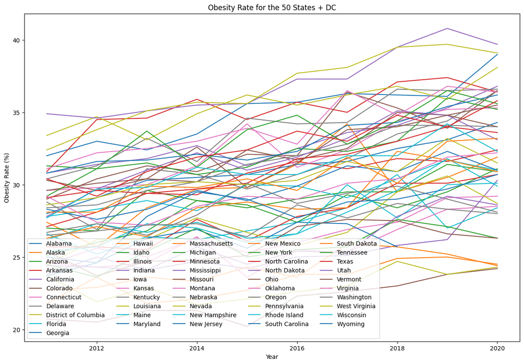

```python
#plot the obesity dataframe and make the figure size big enough
plt = obesity.plot(figsize=(15, 10))
#places the legend in the lower left, puts them in 5 columns, and makes the font size 10
plt.legend(loc="lower left", ncol=5, prop={'size': 10})
#set the title and ylabel of the plot
plt.set_ylabel("Obesity Rate (%)")
plt.set_title("Obesity Rate for the 50 States + DC")
```

Woah! That's a lot of data. One of the evident trends from this plot we just made is the steady increase in obesity rate in just the past 10 years. That blows my mind that in such a short timeframe can we see change from the data. This is just a sample plot to play around with the plot functions. There are plenty of charts you can use to plot the data. I decided on a line chart here becuase we had so many years worth of data. The problem with this many states is the lines become very garbled such that there really isn't any way to tell apart the different states. Why don't we make it so taht we can only see a general trend line. We can also use the power of dataframes and pandas to plot the average of all the states.

```python
#gives us the transpose to make things easier to average and plot
obesity_avg = obesity.T
#takes the average of the state columns and rounds the value to 2 decimal places
obesity_avg.loc["Average"] = obesity_avg.mean().round(2)

obesity_avg.tail()
```

| Year State | 2011 | 2012 | 2013 | 2014 | 2015 | 2016 | 2017 | 2018 | 2019 | 2020 |
| --- | --- | --- | --- | --- | --- | --- | --- | --- | --- | --- |
| Washington | 26.50 | 26.80 | 27.20 | 27.30 | 26.40 | 28.60 | 27.7 | 28.7 | 28.30 | 28.00 |
| West Virginia | 32.40 | 33.80 | 35.10 | 35.70 | 35.60 | 37.70 | 38.1 | 39.5 | 39.70 | 39.10 |
| Wisconsin | 27.70 | 29.70 | 29.80 | 31.20 | 30.70 | 30.70 | 32.0 | 32.0 | 34.20 | 32.30 |
| Wyoming | 25.00 | 24.60 | 27.80 | 29.50 | 29.00 | 27.70 | 28.8 | 29.0 | 29.70 | 30.70 |
| Average | 27.59 | 27.94 | 28.65 | 29.23 | 29.28 | 29.79 | 30.6 | 31.3 | 32.03 | 32.06 |

The reason we want to transpose here is the focus of the data is no longer on the specific years, but the overall average of all of the states per year. We should create a new column at the end of this dataframe. We can do this easily with df.mean().

```
(20.0, 40.0)
```

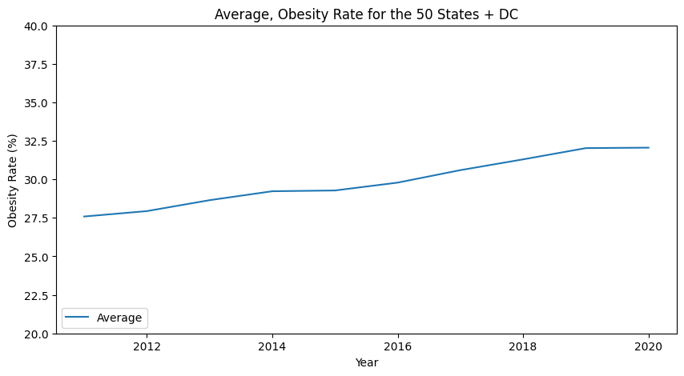

```python
#plot the obesity dataframe and make the figure size big enough
plt = obesity_avg.loc["Average"].plot(figsize=(10, 5))
#places the legend in the lower left, puts them in 5 columns, and makes the font size 10
plt.legend(loc="lower left", ncol=5, prop={'size': 10})
#set the title and ylabel of the plot
plt.set_ylabel("Obesity Rate (%)")
plt.set_title("Average, Obesity Rate for the 50 States + DC")
#resizes the y axis to bring a bit more context into the numbers
plt.set_ylim(20, 40)
```

This simple yet meaningful plot allows us to see the average of all that garbled mess of data each state indicated. Although the previous graph obviously indicated an overall rise, we couldn't confirm there really was an increase without actually taking an average. This plot confirms our assumption that nationwide, obesity rates have been rising.

Now we need to set out to do what was originally planned. We want to see whether there is a correlation between obesity and education.

First of all, we only want a single obesity value for each state. While in the previous section I reduced each year to a single number for the whole country, this time we're doing the average on the other axis. We're getting one number that represents the obesity of each state.

```python
#find the average for each state rather than each year
obesity.loc["Average"] = obesity.mean()

obesity
```

| State Year | Alabama | Alaska | Arizona | Arkansas | California | Colorado | Connecticut | Delaware | District of Columbia | Florida | ... | South Dakota | Tennessee | Texas | Utah | Vermont | Virginia | Washington | West Virginia | Wisconsin | Wyoming |
| --- | --- | --- | --- | --- | --- | --- | --- | --- | --- | --- | --- | --- | --- | --- | --- | --- | --- | --- | --- | --- | --- |
| 2011 | 32.00 | 27.40 | 25.10 | 30.9 | 23.80 | 20.70 | 24.50 | 28.80 | 23.70 | 26.60 | ... | 28.10 | 29.20 | 30.40 | 24.40 | 25.40 | 29.20 | 26.50 | 32.40 | 27.70 | 25.00 |
| 2012 | 33.00 | 25.70 | 26.00 | 34.5 | 25.00 | 20.50 | 25.60 | 26.90 | 21.90 | 25.20 | ... | 28.10 | 31.10 | 29.20 | 24.30 | 23.70 | 27.40 | 26.80 | 33.80 | 29.70 | 24.60 |
| 2013 | 32.40 | 28.40 | 26.80 | 34.6 | 24.10 | 21.30 | 25.00 | 31.10 | 22.90 | 26.40 | ... | 29.90 | 33.70 | 30.90 | 24.10 | 24.70 | 27.20 | 27.20 | 35.10 | 29.80 | 27.80 |
| 2014 | 33.50 | 29.70 | 28.90 | 35.9 | 24.70 | 21.30 | 26.30 | 30.70 | 21.70 | 26.20 | ... | 29.80 | 31.20 | 31.90 | 25.70 | 24.80 | 28.50 | 27.30 | 35.70 | 31.20 | 29.50 |
| 2015 | 35.60 | 29.80 | 28.40 | 34.5 | 24.20 | 20.20 | 25.30 | 29.70 | 22.10 | 26.80 | ... | 30.40 | 33.80 | 32.40 | 24.50 | 25.10 | 29.20 | 26.40 | 35.60 | 30.70 | 29.00 |
| 2016 | 35.70 | 31.40 | 29.00 | 35.7 | 25.00 | 22.30 | 26.00 | 30.70 | 22.60 | 27.40 | ... | 29.60 | 34.80 | 33.70 | 25.40 | 27.10 | 29.00 | 28.60 | 37.70 | 30.70 | 27.70 |
| 2017 | 36.30 | 34.20 | 29.50 | 35.0 | 25.10 | 22.60 | 26.90 | 31.80 | 23.00 | 28.40 | ... | 31.90 | 32.80 | 33.00 | 25.30 | 27.60 | 30.10 | 27.70 | 38.10 | 32.00 | 28.80 |
| 2018 | 36.20 | 29.50 | 29.50 | 37.1 | 25.80 | 23.00 | 27.40 | 33.50 | 24.70 | 30.70 | ... | 30.10 | 34.40 | 34.80 | 27.80 | 27.50 | 30.40 | 28.70 | 39.50 | 32.00 | 29.00 |
| 2019 | 36.10 | 30.50 | 31.40 | 37.4 | 26.20 | 23.80 | 29.10 | 34.40 | 23.80 | 27.00 | ... | 33.00 | 36.50 | 34.00 | 29.20 | 26.60 | 31.90 | 28.30 | 39.70 | 34.20 | 29.70 |
| 2020 | 39.00 | 31.90 | 30.90 | 36.4 | 30.30 | 24.20 | 29.20 | 36.50 | 24.30 | 28.40 | ... | 33.20 | 35.60 | 35.80 | 28.60 | 26.30 | 32.20 | 28.00 | 39.10 | 32.30 | 30.70 |
| Average | 34.98 | 29.85 | 28.55 | 35.2 | 25.42 | 21.99 | 26.53 | 31.41 | 23.07 | 27.31 | ... | 30.41 | 33.31 | 32.61 | 25.93 | 25.88 | 29.51 | 27.55 | 36.67 | 31.03 | 28.18 |

11 rows × 51 columns

Great! Now we have the last row of this dataframe as the obesity values for each state. Let's plot it out as a bar chart and see what we get.

```
(20.0, 40.0)
```

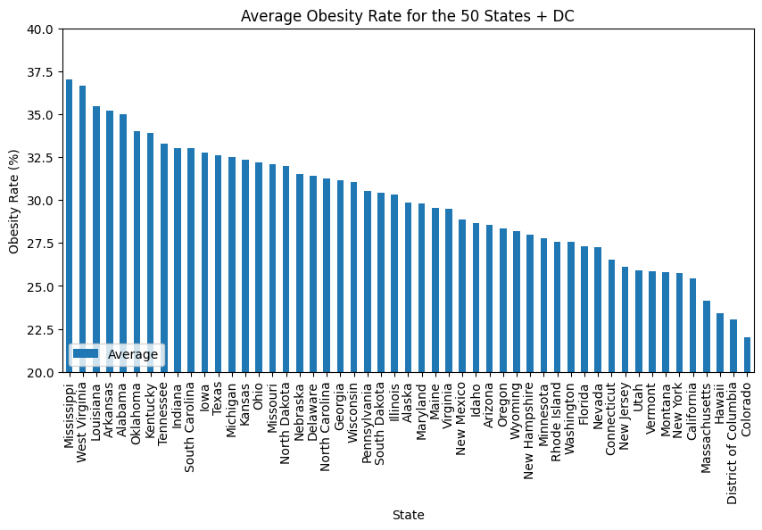

```python
#plot the obesity dataframe and make the figure size big enough
#the sort_values allows us to display the bar chart in descending order
plt = obesity.loc["Average"].sort_values(ascending=False).plot.bar(figsize=(10, 5))
#places the legend in the lower left, puts them in 5 columns, and makes the font size 10
plt.legend(loc="lower left", ncol=5, prop={'size': 10})
#set the title and ylabel of the plot
plt.set_ylabel("Obesity Rate (%)")
plt.set_title("Average Obesity Rate for the 50 States + DC")
#resizes the y axis to bring a bit more context into the numbers
plt.set_ylim(20, 40)
```

Interesting! We can see DC and Colorado on one end and Mississippi and West Virginia on the other end. I'm not surprised at all by the first 10 entries. These are all more rural, poorer states. Colorado on the other hand is a well educated state with a HUGE outdoors culture, which deflates their obesity rate. Let's compare this to the education outcomes.

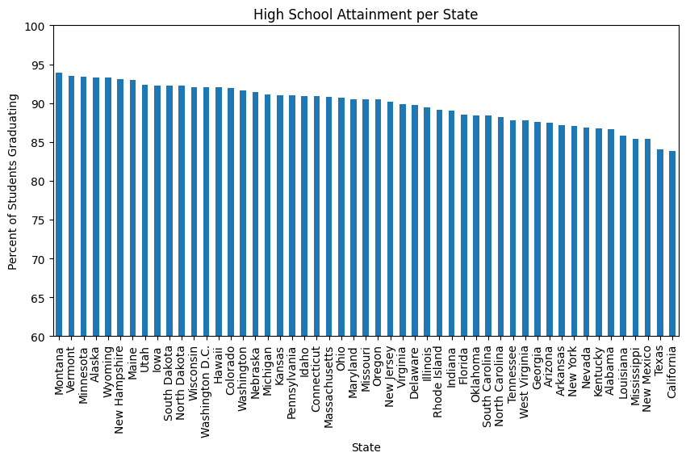

```python
plt = education["High School Attainment (%)"].sort_values(ascending=False).plot.bar(figsize=(10, 5))
plt.set_ylim(60, 100)
plt.set_ylabel("Percent of Students Graduating")
plt.set_title("High School Attainment per State")
```

Wow these values are all quite close together, which I suppose is a good thing. Hmm, maybe high school graduation isn't the best way to differentiate education quality between states, so we'll look at the other metrics' distributions as well.

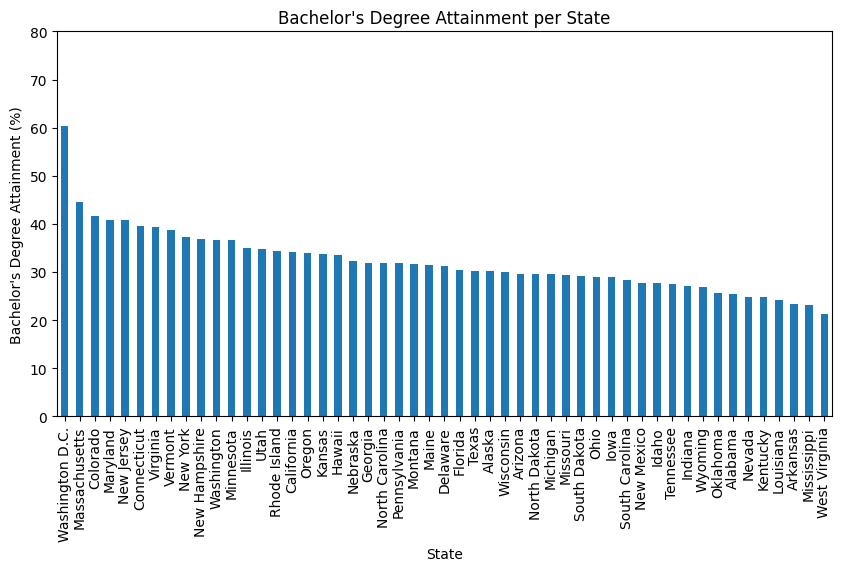

```python
plt = education["Bachelor's Degree Attainment (%)"].sort_values(ascending=False).plot.bar(figsize=(10, 5))
plt.set_ylim(0, 80)
plt.set_ylabel("Bachelor's Degree Attainment (%)")
plt.set_title("Bachelor's Degree Attainment per State")
```

DC is a decent outlier. Being an incredibly urban place sandwiched between two very educated urban areas, there's no wonder DC leads the country in college grads.

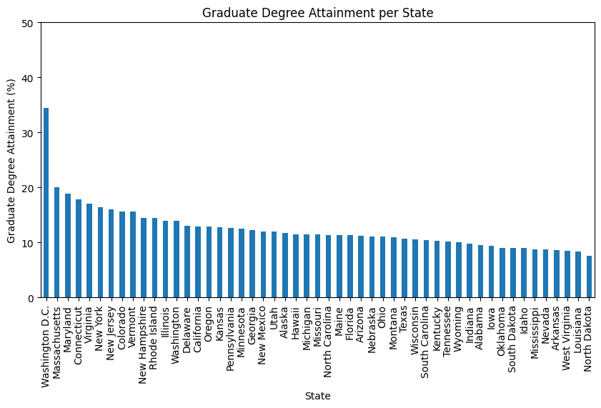

```python
plt = education["Graduate Degree Attainment (%)"].sort_values(ascending=False).plot.bar(figsize=(10, 5))
plt.set_ylim(0, 50)
plt.set_ylabel("Graduate Degree Attainment (%)")
plt.set_title("Graduate Degree Attainment per State")
```

Very similar story to the Bachelor degree data. In DC we see a massive spike representing a huge concentration of highly educated people. This will be interesting to plot out as we see which metric correlates the strongest with obesity.

[figure not shown]

```python
plt = education["Public School Expenditures Per Pupil, K-12 ($ Dollars)"].sort_values(ascending=False).plot.bar(figsize=(10, 5))
plt.set_ylabel("Percent of Students Graduating")
plt.set_title("High School Attainment")
```

There is a TON of variation here with expenditures. Some states are spending twice as much per student as other states.

Enough with the exploring and playing around. Let's try to combine these two datasets into a meaningful scatterplot. First we need to merge the two dataframes together.

```python
obesity = obesity.T

df = education

df["Obesity Rate"] = obesity["Average"]

df.head()
```

| State | Public School Student-Teacher Ratio, K-12 | Public School Expenditures Per Pupil, K-12 ($ Dollars) | Average Salary for Public School Teachers, K-12 ($ Dollars) | High School Attainment (%) | Bachelor's Degree Attainment (%) | Graduate Degree Attainment (%) | Annual College Graduates | Number of 2-Year Colleges | Number of 4-Year Colleges and Universities | Obesity Rate |
| --- | --- | --- | --- | --- | --- | --- | --- | --- | --- | --- |
| Alabama | 17.5 | 9257.0 | 50239.0 | 86.6 | 25.5 | 9.5 | 60282.0 | 30.0 | 42.0 | 34.98 |
| Alaska | 17.0 | 17509.0 | 69474.0 | 93.3 | 30.2 | 11.7 | 4051.0 | 2.0 | 6.0 | 29.85 |
| Arizona | 23.3 | 7772.0 | 47746.0 | 87.5 | 29.7 | 11.2 | 116243.0 | 36.0 | 42.0 | 28.55 |
| Arkansas | 13.8 | 9900.0 | 49017.0 | 87.2 | 23.3 | 8.6 | 31878.0 | 27.0 | 26.0 | 35.20 |
| California | 23.3 | 11420.0 | 81126.0 | 83.8 | 34.2 | 12.9 | 461909.0 | 172.0 | 269.0 | 25.42 |

Awesome! Now we have the combined dataframe that has the various education metric to choose from. Let's start plotting some scatterplots.

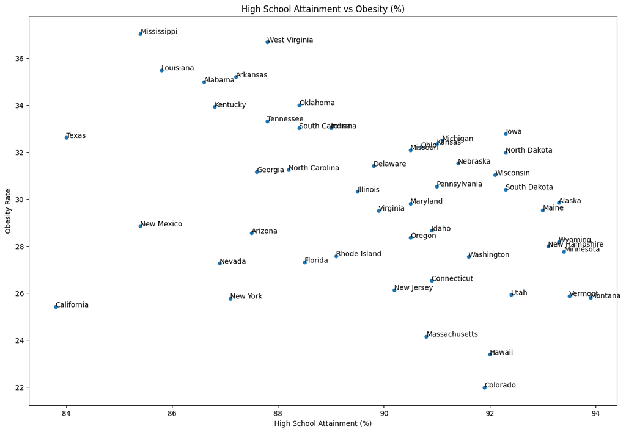

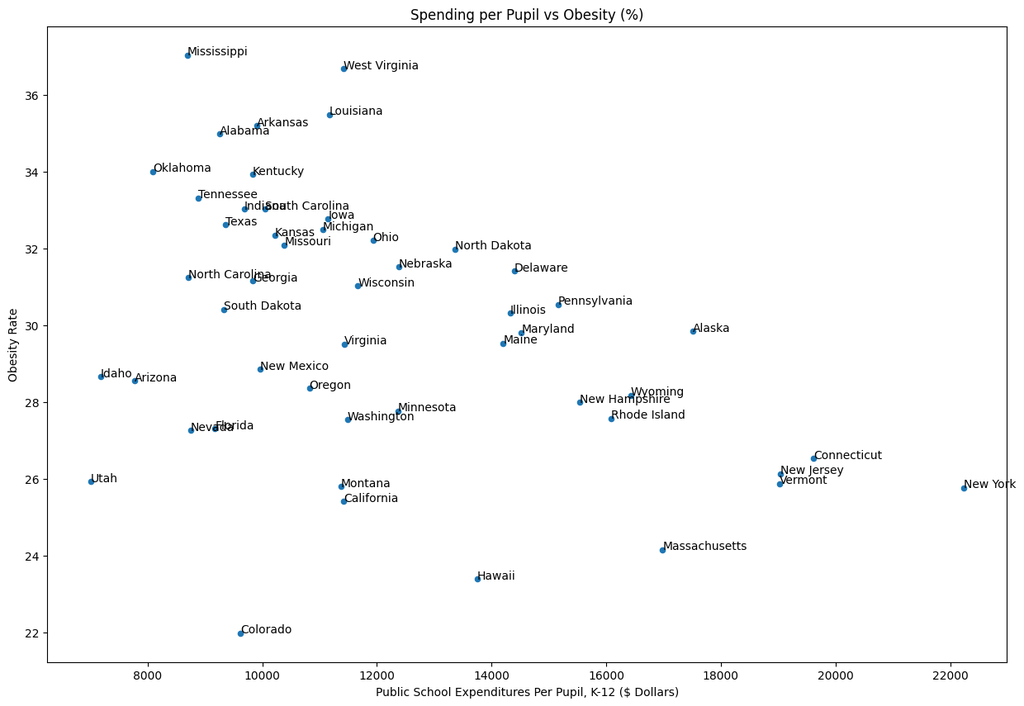

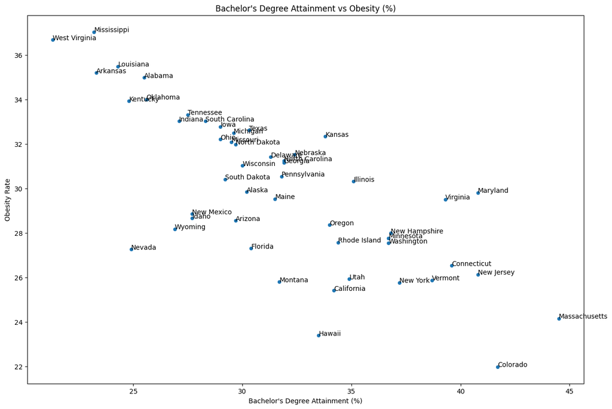

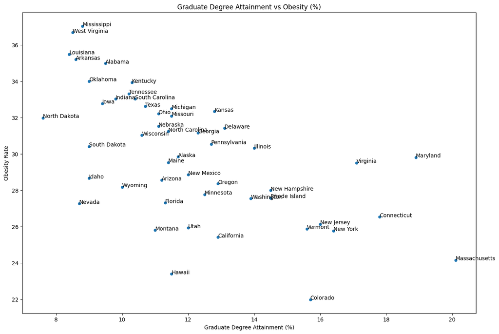

```python
#four standard scatter plots that plot some education metric vs obesity
plt = df.plot.scatter(x="High School Attainment (%)",y="Obesity Rate", figsize=(15, 10))
plt.set_title("High School Attainment vs Obesity (%)")
#allows us to plot a state for each point
for index, row in df.iterrows():
  #make sure each value is actually a number and not NaN
  if not np.isnan(row["High School Attainment (%)"]) and not np.isnan(row["Obesity Rate"]):
    #plot the index at the location of the point
    plt.text(row["High School Attainment (%)"], row["Obesity Rate"], index)


plt = df.plot.scatter(x="Public School Expenditures Per Pupil, K-12 ($ Dollars)", y="Obesity Rate", figsize=(15, 10))
plt.set_title("Spending per Pupil vs Obesity (%)")

for index, row in df.iterrows():
  if not np.isnan(row["High School Attainment (%)"]) and not np.isnan(row["Obesity Rate"]):
    plt.text(row["Public School Expenditures Per Pupil, K-12 ($ Dollars)"], row["Obesity Rate"], index)

plt = df.plot.scatter(x="Bachelor's Degree Attainment (%)", y="Obesity Rate", figsize=(15, 10))
plt.set_title("Bachelor's Degree Attainment vs Obesity (%)")

for index, row in df.iterrows():
  if not np.isnan(row["High School Attainment (%)"]) and not np.isnan(row["Obesity Rate"]):
    plt.text(row["Bachelor's Degree Attainment (%)"], row["Obesity Rate"], index)

plt = df.plot.scatter(x="Graduate Degree Attainment (%)", y="Obesity Rate", figsize=(15, 10))
plt.set_title("Graduate Degree Attainment vs Obesity (%)")

for index, row in df.iterrows():
  if not np.isnan(row["High School Attainment (%)"]) and not np.isnan(row["Obesity Rate"]):
    plt.text(row["Graduate Degree Attainment (%)"], row["Obesity Rate"], index)
```

Wow! It seems that although there is significant variation, we are seeing a trend come to light. The more "educated" the state, the less obese it tends to be. We can see this trend most strongly with the bachelor's degree metric, which seems to correlate the most significantly out of the plotted metrics. We'll test how true this actually is with the exact regression values.

We have a basic scatter plot, but what if we want something fancier, such as a regression line? We can do this by using a nice library called Seaborn, which gives us more advanced and aesthetic plotting functionality. By default, Seaborn scatterplots come with regression lines.

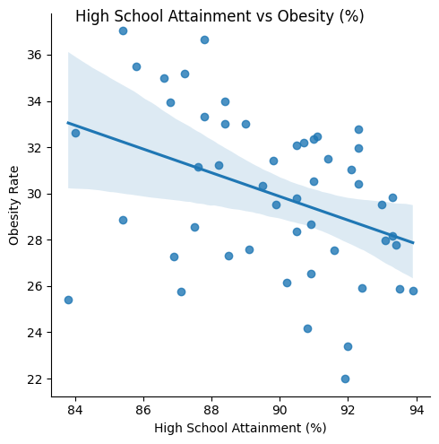

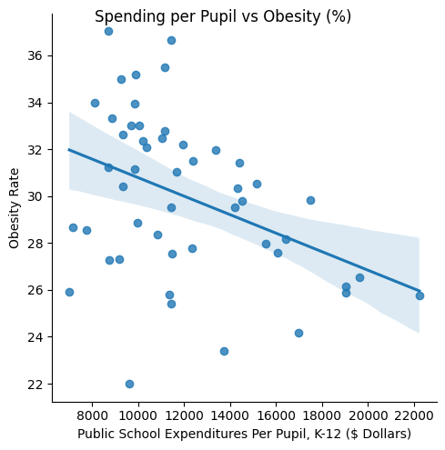

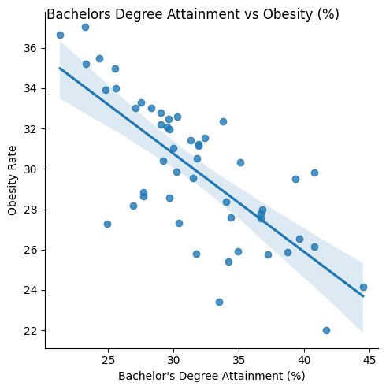

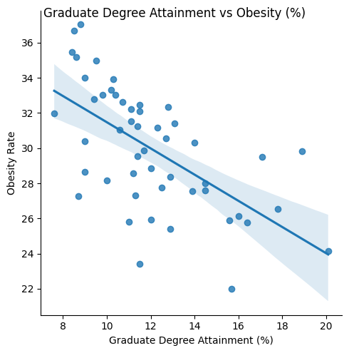

```python
#seaborn plotting with data as the combined dataframe we created
plt = sns.lmplot(x="High School Attainment (%)",y="Obesity Rate", data=df)
plt.fig.suptitle('High School Attainment vs Obesity (%)')

plt = sns.lmplot(x="Public School Expenditures Per Pupil, K-12 ($ Dollars)", y="Obesity Rate", data=df)
plt.fig.suptitle('Spending per Pupil vs Obesity (%)')

plt = sns.lmplot(x="Bachelor's Degree Attainment (%)", y="Obesity Rate", data=df)
plt.fig.suptitle('Bachelors Degree Attainment vs Obesity (%)')

plt = sns.lmplot(x="Graduate Degree Attainment (%)", y="Obesity Rate", data=df)
plt.fig.suptitle('Graduate Degree Attainment vs Obesity (%)')
```

That's pretty cool! Seaborn gives us these nice bounds to be able to see the error it gives. All of these regressions are linear, with Bachelor's metric being particularly noticable.

## Hypothesis Testing

We have a nice visualization of these trends, but sometimes, we need to head back into the world of statistics and do some testing of the data. When we are looking at data like this, a fundamental question we want to answer is how much do these two variables actually correlate with each other, and to what extent is that correlation an actual thing or just something that could happen by random chance.

One of the first things we do when hypothesis testing is state the null hypothesis. The null hypothesis is a statement that the populations we are testing don't contain a statistically significant variation. This means any correlation we do see can be attributed to random chance. Our null hypothesis is: there is no correlation between the educational level of a state and its obesity rate, meaning the coefficients of such regressions are equal to zero, and any variation is just random chance.

Now we want to see if we can reject the null hypothesis. First, we want to utilize another wonderful library called statsmodels, which provides an Ordinary Least Squares regression for our data. This happens to be the same regression Seaborn uses by default so the equations of the lines we get should reflect the lines plotted above.

```python
#statsmodel OLS regression, using High School Attainment as the independent variable and Obesity rate as the dependent
reg = sm.OLS.from_formula("Q('Obesity Rate') ~ Q('High School Attainment (%)') ", df).fit()
print(reg.summary())
```

```
                            OLS Regression Results
==============================================================================
Dep. Variable:      Q('Obesity Rate')   R-squared:                       0.151
Model:                            OLS   Adj. R-squared:                  0.133
Method:                 Least Squares   F-statistic:                     8.511
Date:                Fri, 16 Dec 2022   Prob (F-statistic):            0.00536
Time:                        23:48:54   Log-Likelihood:                -128.60
No. Observations:                  50   AIC:                             261.2
Df Residuals:                      48   BIC:                             265.0
Df Model:                           1
Covariance Type:            nonrobust
===================================================================================================
                                      coef    std err          t      P>|t|      [0.025      0.975]
---------------------------------------------------------------------------------------------------
Intercept                          75.9839     15.778      4.816      0.000      44.259     107.709
Q('High School Attainment (%)')    -0.5123      0.176     -2.917      0.005      -0.865      -0.159
==============================================================================
Omnibus:                        2.917   Durbin-Watson:                   1.587
Prob(Omnibus):                  0.233   Jarque-Bera (JB):                2.724
Skew:                          -0.505   Prob(JB):                        0.256
Kurtosis:                       2.462   Cond. No.                     3.10e+03
==============================================================================

Notes:
[1] Standard Errors assume that the covariance matrix of the errors is correctly specified.
[2] The condition number is large, 3.1e+03. This might indicate that there are
strong multicollinearity or other numerical problems.
```

```python
reg = sm.OLS.from_formula("Q('Obesity Rate') ~ Q('Public School Expenditures Per Pupil, K-12 ($ Dollars)')", df).fit()
print(reg.summary())
```

```
                            OLS Regression Results
==============================================================================
Dep. Variable:      Q('Obesity Rate')   R-squared:                       0.158
Model:                            OLS   Adj. R-squared:                  0.141
Method:                 Least Squares   F-statistic:                     9.031
Date:                Fri, 16 Dec 2022   Prob (F-statistic):            0.00421
Time:                        23:48:54   Log-Likelihood:                -128.37
No. Observations:                  50   AIC:                             260.7
Df Residuals:                      48   BIC:                             264.6
Df Model:                           1
Covariance Type:            nonrobust
===============================================================================================================================
                                                                  coef    std err          t      P>|t|      [0.025      0.975]
-------------------------------------------------------------------------------------------------------------------------------
Intercept                                                      34.7373      1.650     21.052      0.000      31.420      38.055
Q('Public School Expenditures Per Pupil, K-12 ($ Dollars)')    -0.0004      0.000     -3.005      0.004      -0.001      -0.000
==============================================================================
Omnibus:                        2.455   Durbin-Watson:                   1.944
Prob(Omnibus):                  0.293   Jarque-Bera (JB):                1.828
Skew:                          -0.465   Prob(JB):                        0.401
Kurtosis:                       3.113   Cond. No.                     4.55e+04
==============================================================================

Notes:
[1] Standard Errors assume that the covariance matrix of the errors is correctly specified.
[2] The condition number is large, 4.55e+04. This might indicate that there are
strong multicollinearity or other numerical problems.
```

```python
reg = sm.OLS.from_formula("Q('Obesity Rate') ~ Q('Bachelor\\'s Degree Attainment (%)')", df).fit()
print(reg.summary())
```

```
                            OLS Regression Results
==============================================================================
Dep. Variable:      Q('Obesity Rate')   R-squared:                       0.553
Model:                            OLS   Adj. R-squared:                  0.544
Method:                 Least Squares   F-statistic:                     59.50
Date:                Fri, 16 Dec 2022   Prob (F-statistic):           5.99e-10
Time:                        23:48:54   Log-Likelihood:                -112.53
No. Observations:                  50   AIC:                             229.1
Df Residuals:                      48   BIC:                             232.9
Df Model:                           1
Covariance Type:            nonrobust
==========================================================================================================
                                             coef    std err          t      P>|t|      [0.025      0.975]
----------------------------------------------------------------------------------------------------------
Intercept                                 45.3464      2.021     22.441      0.000      41.283      49.409
Q('Bachelor\'s Degree Attainment (%)')    -0.4866      0.063     -7.713      0.000      -0.613      -0.360
==============================================================================
Omnibus:                        5.426   Durbin-Watson:                   2.046
Prob(Omnibus):                  0.066   Jarque-Bera (JB):                4.924
Skew:                          -0.768   Prob(JB):                       0.0853
Kurtosis:                       3.042   Cond. No.                         195.
==============================================================================

Notes:
[1] Standard Errors assume that the covariance matrix of the errors is correctly specified.
```

```python
reg = sm.OLS.from_formula("Q('Obesity Rate') ~ Q('Graduate Degree Attainment (%)')", df).fit()
print(reg.summary())
```

```
                            OLS Regression Results
==============================================================================
Dep. Variable:      Q('Obesity Rate')   R-squared:                       0.378
Model:                            OLS   Adj. R-squared:                  0.365
Method:                 Least Squares   F-statistic:                     29.19
Date:                Fri, 16 Dec 2022   Prob (F-statistic):           2.02e-06
Time:                        23:48:55   Log-Likelihood:                -120.80
No. Observations:                  50   AIC:                             245.6
Df Residuals:                      48   BIC:                             249.4
Df Model:                           1
Covariance Type:            nonrobust
=======================================================================================================
                                          coef    std err          t      P>|t|      [0.025      0.975]
-------------------------------------------------------------------------------------------------------
Intercept                              38.9187      1.702     22.871      0.000      35.497      42.340
Q('Graduate Degree Attainment (%)')    -0.7445      0.138     -5.403      0.000      -1.022      -0.467
==============================================================================
Omnibus:                        2.387   Durbin-Watson:                   2.087
Prob(Omnibus):                  0.303   Jarque-Bera (JB):                2.244
Skew:                          -0.497   Prob(JB):                        0.326
Kurtosis:                       2.699   Cond. No.                         54.0
==============================================================================

Notes:
[1] Standard Errors assume that the covariance matrix of the errors is correctly specified.
```

The p-values for all of these OLS regressions were below the accepted value of 0.05, meaning we can reject the null hypothesis and say there is a statistically significant correlation between education and obesity rate for ALL the metrics we saw. This is solid evidence that there indeed is a correlation.

Another interesting thing we can investigate is the actual correlation coefficients. These coefficients tell us the slope of the line of the regression we found:

For every 1% increase in High school attainment rate, obesity rate went down -0.5123 percentage points. For every 1% increase in Bachelor's attainment rate, obesity rate went down -0.4866 percentage points. For every 1% increase in Master's attainment rate, obesity rate went down -0.7445 percentage points. For every 1000 dollar increase in Spending per Pupil, obesity rate went down -0.40 percentage points.

## Conclusions/Insights Attained

Wow! We have almost reached the end of the data science pipeline. We've made it. Finally, we need to reflect on our findings and whether we've answered our questions.

One thing is for sure: there certainly A correlation between obesity and education. The more highly educated the state, the lower the state's obesity rate tends to be. We see from our bar chart visualizations that the poorest and least educated states tended to have the highest obesity rates. We proved that by plotting out the graphs and using Seaborn to graph out a regression line that indicated the trend. We then used the statsmodel to find specific coefficients that affected the education metric's correlation with obesity.

Different variables correlated differently. We did some thinking about the data we had at the beginning to figure out which metrics would be the most interesting/useful to plot out. We decided on the money spent per pupil, the high school graduation rates, and college degree attainment rates were the most promising metrics to calculate a correlation with obesity. The r squared values showed that there is the most significant correlation for the Bachelor's attainment rate metric for education.

In the end, I found a real world topic I was interested in proving. The hypothesis of mine isn't exactly groundbreaking. I suggested that there was likely a correlation between obesity and education, in that less educated states would have higher obesity rates because less educated people tend to eat less healthy and exercise less. However this is simply my intuition; I had no idea if data I collect online would actually reflect this trend. Thus I set to find out whether there actually was a trend, collecting data from two independent sources and plotting the data. We wrangled the data, made it easier to work with, and then plotted. We then did some hypothesis testing and came to the conclusion that our data demonstrated there DOES exist a correlation, and that Bachelor's degree attainment rates were the best predictor. Overall, I learned a lot. This will definitely encourage me to use data science more in the future to investigate things I'm interested in.